# Bangladesh surveillance greyspots

Elonia

## Notes

The goal of this study is to identify how well the Bangladesh national cholera surveillance system captures:

1. the Bangladeshi population
2. the Bangladeshi population living in high, medium, and low risk cholera areas

We define cholera surveillance zones as geographies surrounding one of the 22 cholera sentinel hospitals. Surveillance zones are defined as the area enclosed within a circular buffer with a radius of x km surrounding the coordinates of a given sentinel hospital. Subdistrict, district, and tertiary care hospitals may have different radii.

The values we want to estimate include:

1. percentage of the population living in cholera surveillance zones
2. number and percentage of infections residing in cholera surveillance zones within the last year
3. number and percentage of infections residing in cholera surveillance zones that are in high, medium, and low infection risk areas
4. number and percentage of people living in high, medium, and low infection risk areas that would be captured by cholera surveillance zones

We use the following threshold for defining high, medium, and low risk infection areas:

- RR >= 1.5 is high risk
- 0.5 < RR < 1.5 is medium risk
- RR <= 0.5 is low risk

## Identifying the cholera surveillance zone

There are 22 sentinel hospital sites (Table 1).

Table 1: **Sentinel hospital IDs and locations.**

| ID | Hospital | Division | Type | Latitude | Longitude |
| --- | --- | --- | --- | --- | --- |
| 1 | District Hospital Norshingdi | Dhaka | district | 23.92022 | 90.71846 |
| 2 | Adhunik Sadar Hospital Habiganj | Sylhet | district | 24.37346 | 91.41769 |
| 3 | District Sadar Hospital Cox’s Bazar | Chittagong | district | 21.44159 | 91.97683 |
| 4 | Adhunik Sadar Hospital Naogaon | Rajshahi | district | 24.82262 | 88.93793 |
| 5 | General Hospital Patuakhali | Barisal | tertiary | 22.35885 | 90.32737 |
| 6 | Adhunik Sadar Hospital Thakurgaon | Rangpur | district | 26.02952 | 88.47657 |
| 7 | District Sadar Hospital Satkhira | Khulna | district | 22.69032 | 89.04679 |
| 8 | Dhaka Medical College Dhaka | Dhaka | tertiary | 23.72539 | 90.39701 |
| 9 | Uttara Adhunik Medical College Hospital | Dhaka | tertiary | 23.87482 | 90.39675 |
| 10 | Bangladesh Institute of Tropical and Infectious Diseases Chittagong | Chittagong | tertiary | 22.39274 | 91.75855 |
| 11 | General Hospital Tangail | Dhaka | district | 24.26432 | 89.92484 |
| 12 | General Hospital Narayanganj | Dhaka | district | 23.62455 | 90.50121 |
| 13 | Sadar Hospital Chuadanga | Khulna | district | 23.63517 | 88.84640 |
| 14 | General Hospital Meherpur | Khulna | district | 23.77835 | 88.64240 |
| 15 | General Hospital Comilla | Chittagong | district | 23.45596 | 91.18204 |
| 16 | Upazila Health Complex Chaugachha Jesssore | Khulna | subdistrict | 23.25958 | 89.02446 |
| 17 | General Hospital Kusthia | Khulna | district | 23.90120 | 89.12426 |
| 18 | Upazila Health Complex Madan | Mymensingh | subdistrict | 24.71669 | 90.94530 |
| 19 | Upazila Health Complex Chhatak Sunamganj | Sylhet | subdistrict | 25.03337 | 91.66869 |
| 20 | Upazila Health Complex Mathbariya | Barisal | subdistrict | 22.28575 | 89.95365 |
| 21 | Upazila Health Complex Bakerganj | Barisal | subdistrict | 22.53881 | 90.34633 |
| 22 | Health Complex Shibganj | Rajshahi | subdistrict | 24.68770 | 88.15844 |

Table 2: **Proportion of population living within sentinel hospital buffers.**

| Buffer (Subdistrict-District-Tertiary in km) | Pop | Proportion |
| --- | --- | --- |
| 10-10-30 | 35114090 | 0.2159389 |
| 10-20-30 | 44639036 | 0.2745138 |
| 15-25-35 | 54991285 | 0.3381764 |
| 20-20-30 | 48362202 | 0.2974099 |

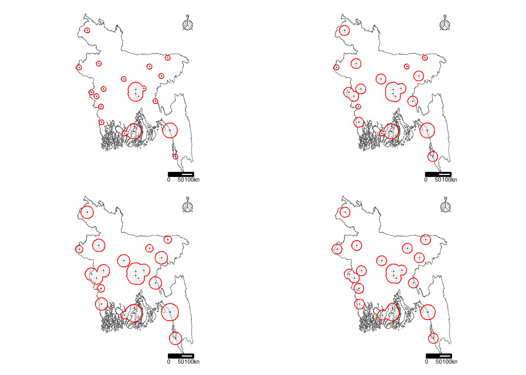

Figure 3: **Map of** 10-10-30km, 10-20-30km, 15-25-35km, 20-20-30km **buffers around (subdistrict-district-tertiary care) sentinel hospital sites (left to right, top row to bottom row, respectively).**

## Mapping infections with serological data

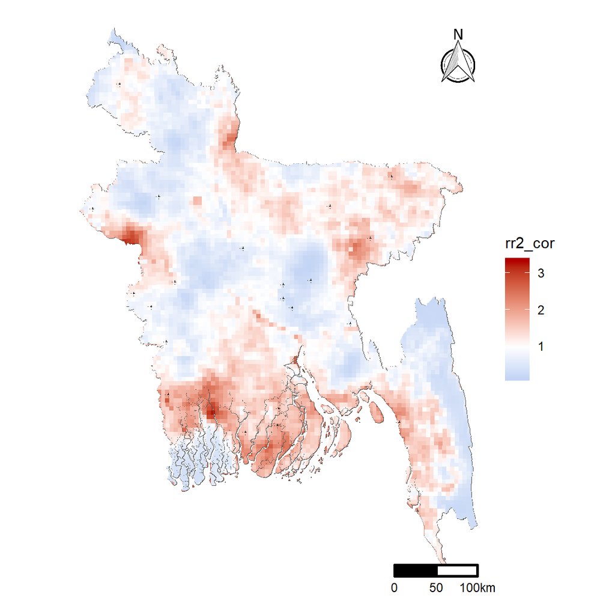

Figure 4: **Risk of infection relative to population-weighted mean**

### Determining infection risk categories

We examined the distribution of relative risks (Figure 5) and estimated infections (Figure 6) by grid cell in order to identify thresholds for binning infection risk into categories .

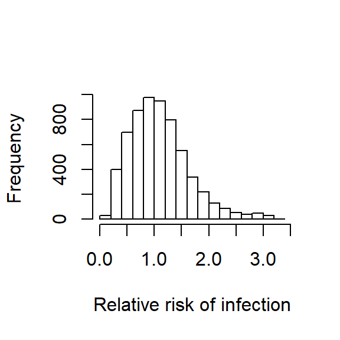

Figure 5: **Histogram of the risk of infection relative to population-weighted mean**

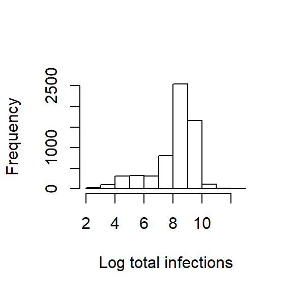

Figure 6: **Histogram of the log total number of infections**

```
## [1] "Distribution of relative risk across by 5 km x 5 km cell"
```

```
## 0.1328026 0.6989712 1.026415 1.097483 1.385071 3.336598
```

```
## [1] "Distribution of number of infections by 5 km x 5 km cell"
```

```
## 8.390758 2260.931 5155.061 6718.67 8748.352 319525.5
```

Table 3: **Population living in each risk category.** The population living in high, moderate, and low risk areas according to relative risk and infection thresholds across all of Bangladesh.

| Risk Level | Population (RR threshold) | Population (Infection threshold) |
| --- | --- | --- |
| High | 22052485 | 127754236 |
| Moderate | 115134174 | 29636755 |
| Low | 25424605 | 5220273 |

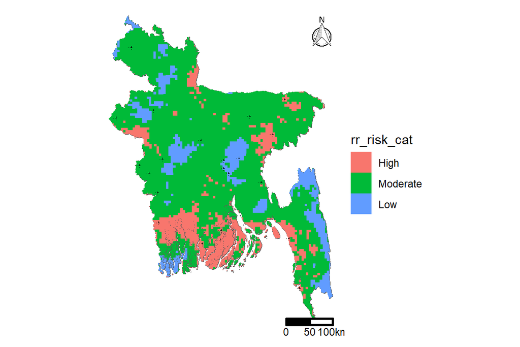

Figure 7: **Cholera risk map as categorized by the risk of infection relative to a population-weighted mean**

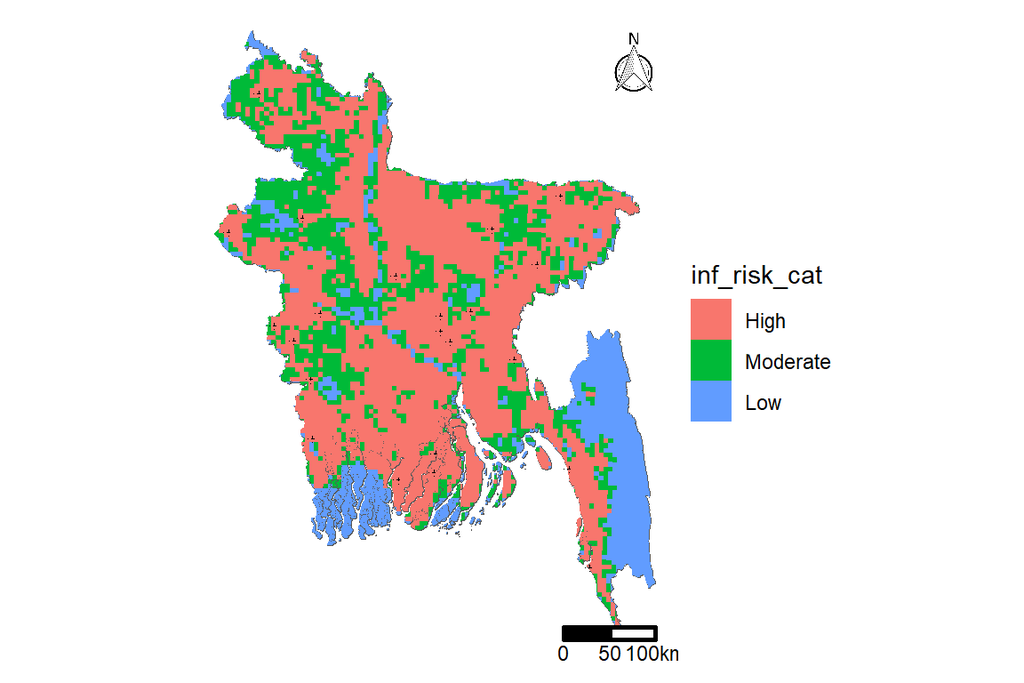

Figure 8: **Cholera risk map as categorized by number of infections**

## Intersecting infections and the cholera surveillance zone

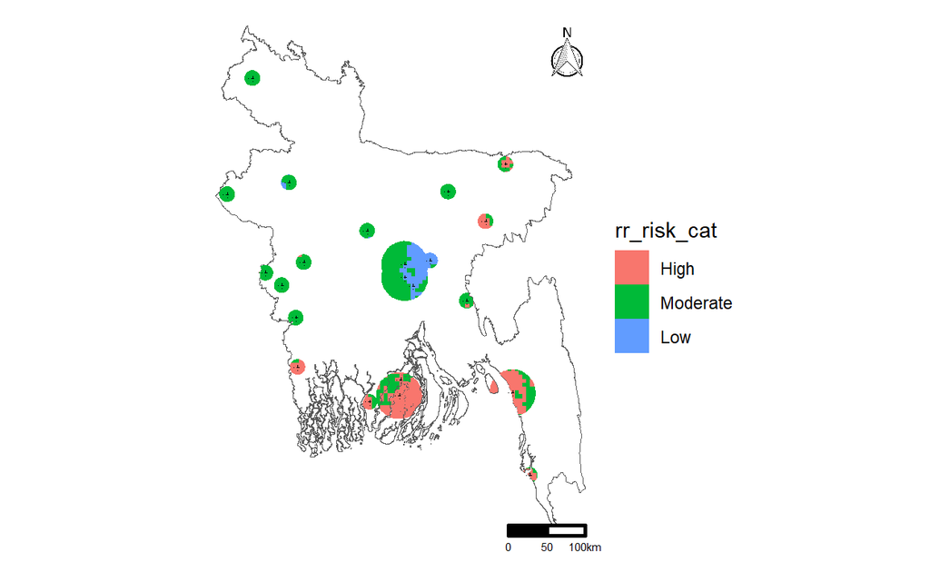

Figure 9: **Infection risk, as categorized by relative risk, within cholera surveillance zones (10-10-30km for subdistrict, district, and tertiary care hospitals)**

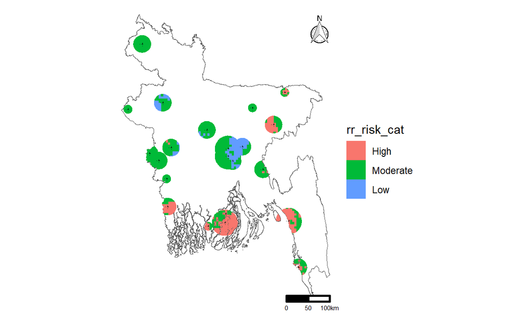

Figure 10: **Infection risk, as categorized by relative risk, within cholera surveillance zones (10-20-30km for subdistrict, district, and tertiary care hospitals)**

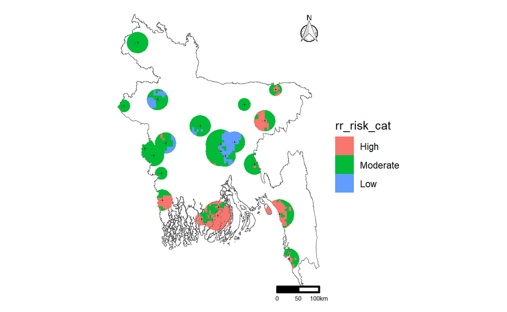

Figure 11: **Infection risk, as categorized by relative risk, within cholera surveillance zones (15-25-35km for subdistrict, district, and tertiary care hospitals)**

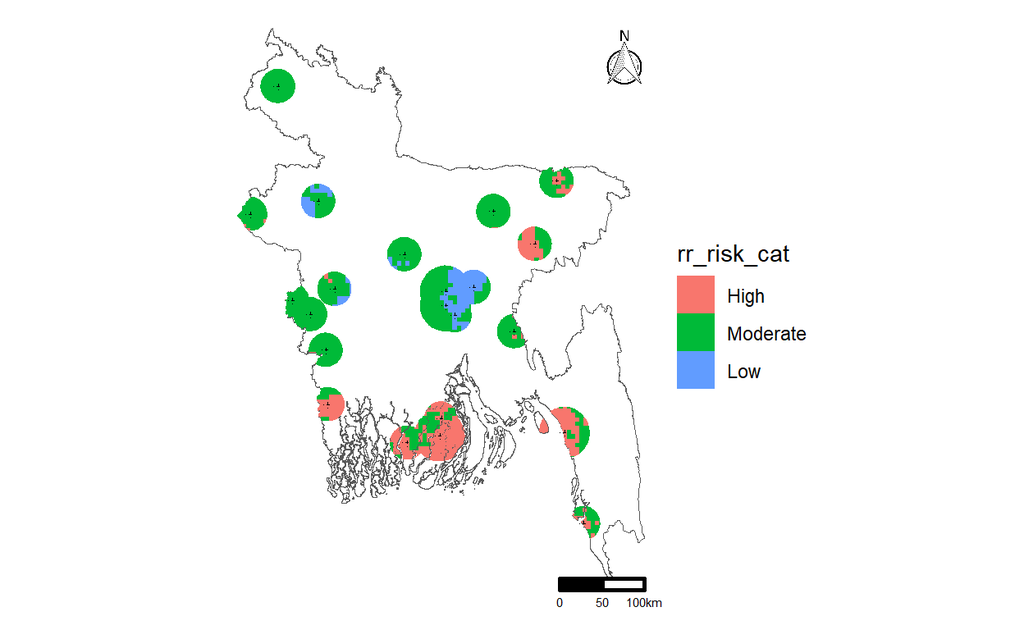

Figure 12: **Infection risk, as categorized by relative risk, within cholera surveillance zones (20-20-30km for subdistrict, district, and tertiary care hospitals)**

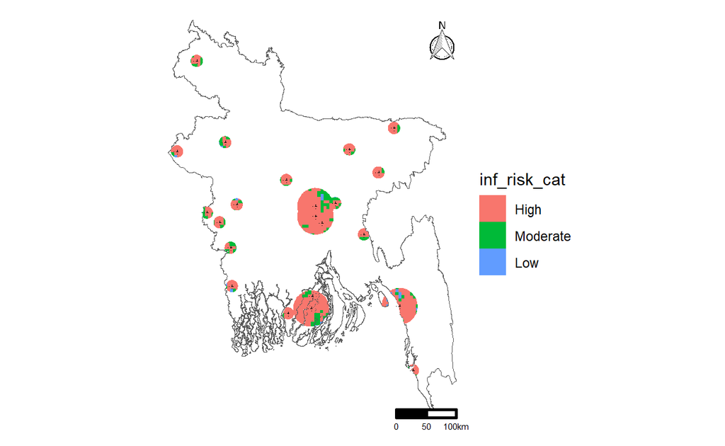

Figure 13: **Infection risk, as categorized by number of infections, within cholera surveillance zones (10-10-30km for subdistrict, district, and tertiary care hospitals)**

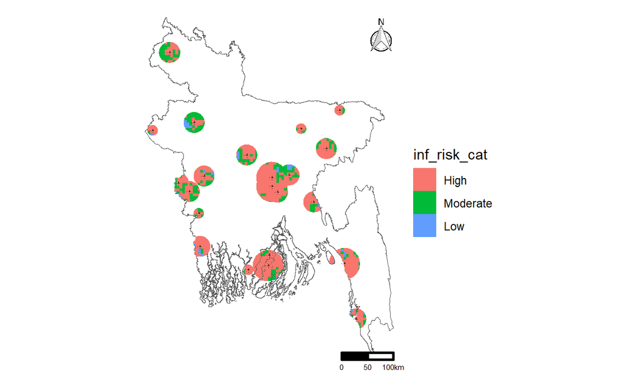

Figure 14: **Infection risk, as categorized by number of infections, within cholera surveillance zones (10-20-30km for subdistrict, district, and tertiary care hospitals)**

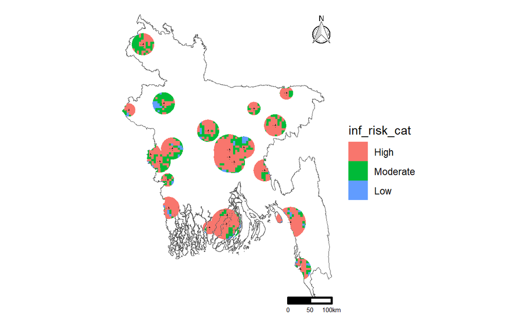

Figure 15: **Infection risk, as categorized by number of infections, within cholera surveillance zones (15-25-35km for subdistrict, district, and tertiary care hospitals)**

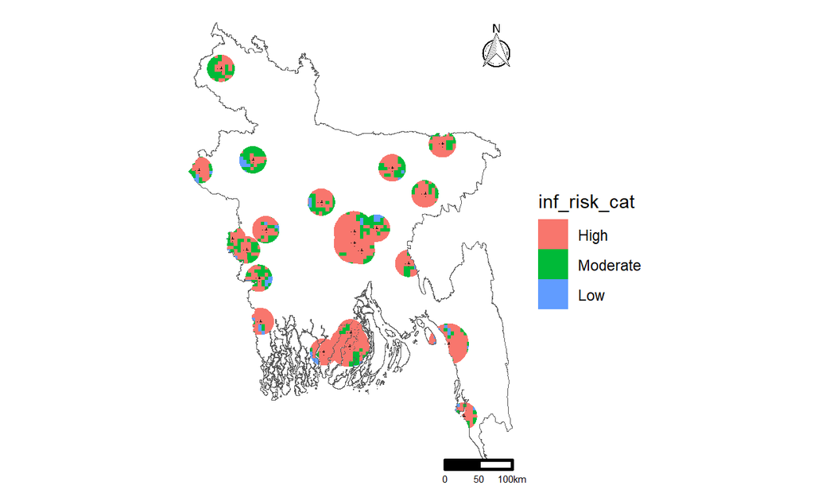

Figure 16: **Infection risk, as categorized by number of infections, within cholera surveillance zones (20-20-30km for subdistrict, district, and tertiary care hospitals)**

We overlaid the cholera surveillance zone with the binned infection risk maps to examine the distribution of risks in the surveilled areas. This was done for infection risk as categorized by relative risk (Figure 9 - Figure 12) and by the total number of infections (Figure 13 - Figure 16).

We also identified high risk populations that were not captured by the surveillance zone, as categorized by relative risk (Figure 17 - Figure 18) and by total infections (Figure 19 - Figure 20).

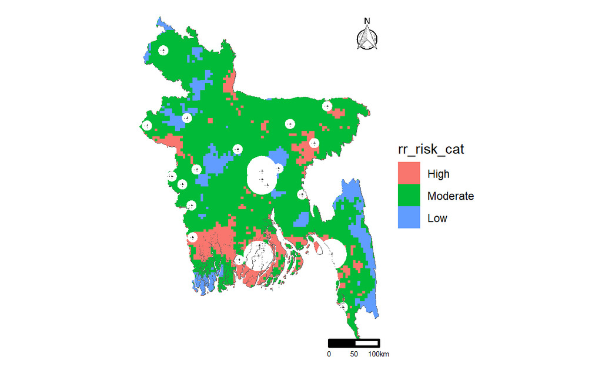

Figure 17: **Infection risk, as categorized by relative risk, outside of cholera surveillance zones (10-10-30km for subdistrict, district, and tertiary care hospitals)**

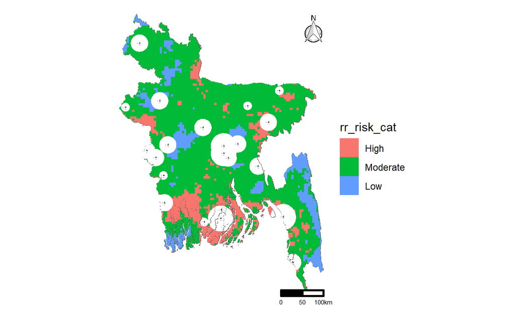

Figure 21: **Infection risk, as categorized by relative risk, outside of cholera surveillance zones (10-20-30km for subdistrict, district, and tertiary care hospitals)**

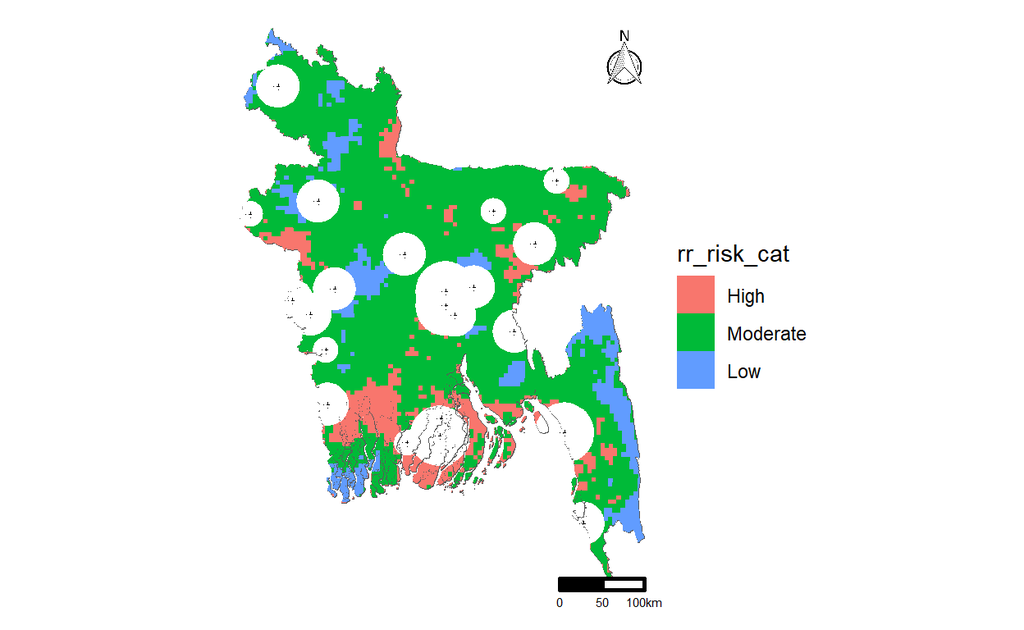

Figure 22: **Infection risk, as categorized by relative risk, outside of cholera surveillance zones (15-25-35km for subdistrict, district, and tertiary care hospitals)**

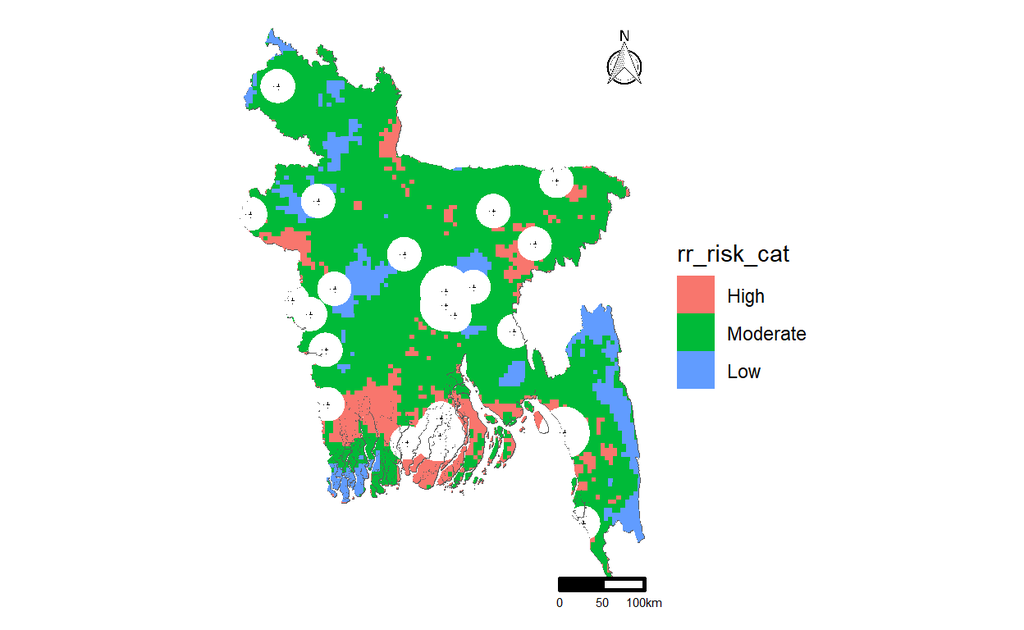

Figure 18: **Infection risk, as categorized by relative risk, outside of cholera surveillance zones (20-20-30km for subdistrict, district, and tertiary care hospitals)**

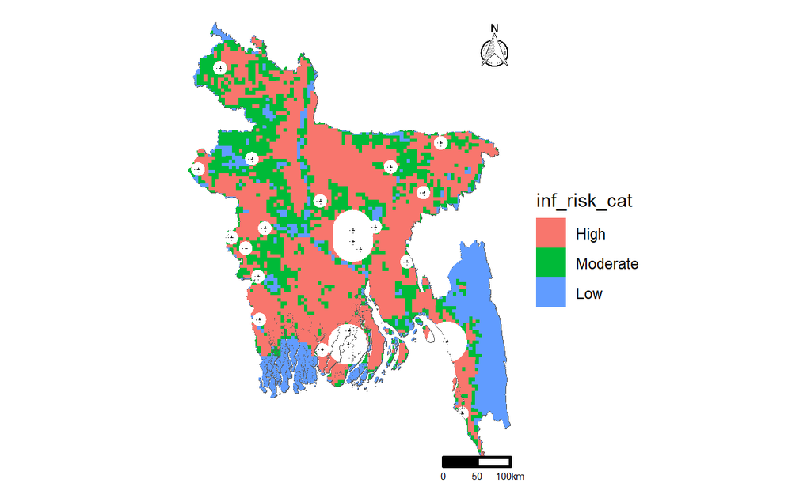

Figure 19: **Infection risk, as categorized by number of infections, outside of cholera surveillance zones (10-10-30km for subdistrict, district, and tertiary care hospitals)**

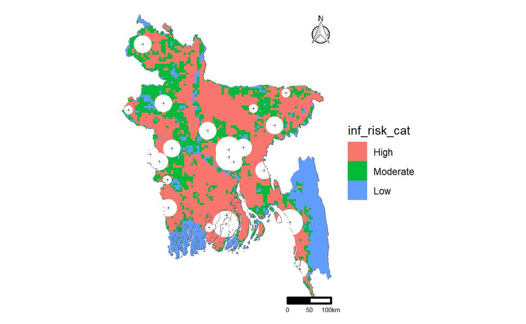

Figure 23: **Infection risk, as categorized by number of infections, outside of cholera surveillance zones (10-20-30km for subdistrict, district, and tertiary care hospitals)**

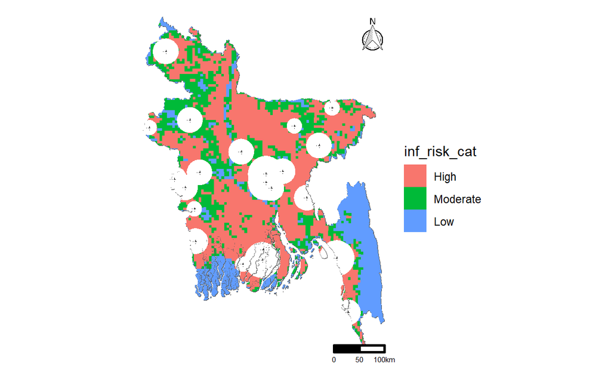

Figure 24: **Infection risk, as categorized by number of infections, outside of cholera surveillance zones (15-25-35km for subdistrict, district, and tertiary care hospitals)**

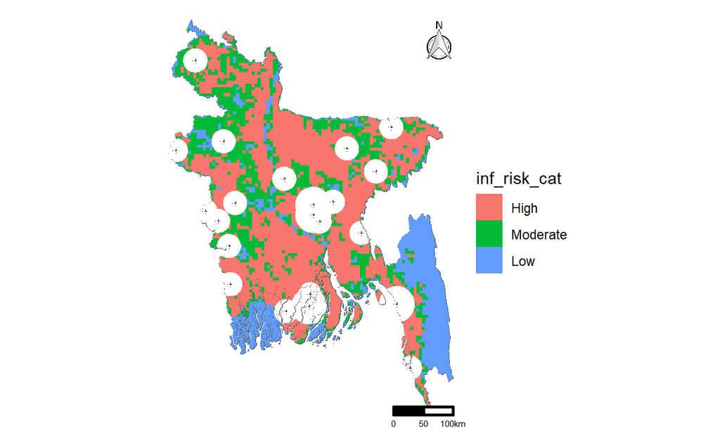

Figure 20: **Infection risk, as categorized by number of infections, outside of cholera surveillance zones (20-20-30km for subdistrict, district, and tertiary care hospitals)**

### Populations in the cholera surveillance zone

We examined the number of infections falling within each set of buffer distances. We also calculated the percentage of the buffer population infected, and the percentage of total infections across Bangladesh represented for each set of buffer distances (Table 4).

Table 4: **Number and percent infections that may be captured in cholera surveillance zones.** The percent infected represents the percentage of infected individuals captured within the cholera surveillance zone out of all infected individuals in Bangladesh.

| Buffer size | Buffer population | Number infected | Infections in buffer pop (%) | Infections in BGD (%) |
| --- | --- | --- | --- | --- |
| 10-10-30 | 35114090 | 9066520 | 25.82 | 21.67 |
| 10-20-30 | 44639036 | 11621152 | 26.03 | 27.78 |
| 15-25-35 | 54991285 | 14443776 | 26.27 | 34.52 |
| 20-20-30 | 48362202 | 12988710 | 26.86 | 31.05 |

We then examined the distribution of relative-risk-based categories (Table 5) and number-of-infection-based categories (Table 6) within the cholera surveillance zone, for each buffer distance.

Table 5: **Number and percent infections that may be captured in cholera surveillance zones, categorized by relative risk.** The infections in surveillance zone represents the percentage of infected people in high/moderate/low risk grid cells among all infections within the cholera surveillance zone. The population in surveillance zone represents the percentage of people living in high/moderate/low risk grid cells among all people within the cholera surveillance zone. The distribution should across risk categories should sum to 100% for each set of buffer sizes.

| Buffer size | Risk Category | Number Infected | % infections in Surveillance Zone | Population number | % population in Surveillance Zone |
| --- | --- | --- | --- | --- | --- |
| 10-10-30 | High | 2830025 | 31.21 | 6200421 | 15.23 |
| 10-10-30 | Moderate | 4823083 | 53.20 | 20153739 | 49.51 |
| 10-10-30 | Low | 1413412 | 15.59 | 14350826 | 35.26 |
| 10-20-30 | High | 3338508 | 28.73 | 7267961 | 14.04 |
| 10-20-30 | Moderate | 6717921 | 57.81 | 28468877 | 55.00 |
| 10-20-30 | Low | 1564724 | 13.46 | 16020560 | 30.95 |
| 15-25-35 | High | 4010512 | 27.77 | 8699041 | 13.87 |
| 15-25-35 | Moderate | 8768322 | 60.71 | 36835895 | 58.74 |
| 15-25-35 | Low | 1664943 | 11.53 | 17172964 | 27.39 |
| 20-20-30 | High | 3796062 | 29.23 | 8271142 | 14.75 |
| 20-20-30 | Moderate | 7627924 | 58.73 | 31775217 | 56.67 |
| 20-20-30 | Low | 1564724 | 12.05 | 16020560 | 28.57 |

Table 6: **Number and percent infections that may be captured in cholera surveillance zones, categorized by number of infections** The infections in surveillance zone represents the percentage of infected people in high/moderate/low risk grid cells among all infections within the cholera surveillance zone. The population in surveillance zone represents the percentage of people living in high/moderate/low risk grid cells among all people within the cholera surveillance zone. The distribution should across risk categories should sum to 100% for each set of buffer sizes.

| Buffer size | Risk Category | Number Infected | Infections in Surveillance Zone (%) | Population in Surveillance Zone (%) |
| --- | --- | --- | --- | --- |
| 10-10-30 | High | 8459886.90 | 93.31 | 91.54 |
| 10-10-30 | Moderate | 569188.31 | 6.28 | 7.94 |
| 10-10-30 | Low | 37444.39 | 0.41 | 0.52 |
| 10-20-30 | High | 10395815.46 | 89.46 | 86.03 |
| 10-20-30 | Moderate | 1144368.63 | 9.85 | 12.51 |
| 10-20-30 | Low | 80968.39 | 0.70 | 1.45 |
| 15-25-35 | High | 12640100.42 | 87.51 | 83.40 |
| 15-25-35 | Moderate | 1663194.61 | 11.51 | 14.77 |
| 15-25-35 | Low | 140481.28 | 0.97 | 1.84 |
| 20-20-30 | High | 11523818.98 | 88.72 | 85.44 |
| 20-20-30 | Moderate | 1361651.66 | 10.48 | 13.09 |
| 20-20-30 | Low | 103238.88 | 0.79 | 1.47 |

### Populations at different levels of infection risk in Bangladesh

We sought to describe how well the cholera surveillance zones capture High, Moderate, Low populations across the population of Bangladesh and High, Moderate, Low infections among infections in Bangladesh.

We summarized the percentage of high, moderate, and low infection risk populations in Bangladesh that would be captured by cholera surveillance zones at different buffer sizes when risk was categorized both by relative risk (Table 7) and by the number of infections (Table 8).

Table 7: **Number and percent infections that may be captured in Bangladesh, categorized by relative risk.** The captured at-risk population represents the percentage of high/moderate/low risk populations captured by the cholera surveillance zone out of all high/moderate/low risk populations in Bangladesh. The captured infections represents the percentage of infections in high/moderate/low risk grid cells among all infections in high/moderate/low risk grid cells across Bangladesh.

| Buffer size | Risk Category | Buffer Pop (Sero) | Number Infected | Captured At-Risk Pop (%) | Captured Infections (%) |
| --- | --- | --- | --- | --- | --- |
| 10-10-30km | High | 6200421 | 2830025 | 28.12 | 27.28 |
| 10-10-30km | Moderate | 20153739 | 4823083 | 17.50 | 16.64 |
| 10-10-30km | Low | 14350826 | 1413412 | 56.44 | 57.17 |
| 10-20-30km | High | 7267961 | 3338508 | 32.96 | 32.18 |
| 10-20-30km | Moderate | 28468877 | 6717921 | 24.73 | 23.17 |
| 10-20-30km | Low | 16020560 | 1564724 | 63.01 | 63.29 |
| 15-25-35km | High | 8699041 | 4010512 | 39.45 | 38.66 |
| 15-25-35km | Moderate | 36835895 | 8768322 | 31.99 | 30.25 |
| 15-25-35km | Low | 17172964 | 1664943 | 67.54 | 67.34 |
| 20-20-30km | High | 8271142 | 3796062 | 37.51 | 36.59 |
| 20-20-30km | Moderate | 31775217 | 7627924 | 27.60 | 26.31 |
| 20-20-30km | Low | 16020560 | 1564724 | 63.01 | 63.29 |

Table 8: **Number and percent infections that may be captured in Bangladesh, categorized by number of infections.** The captured at-risk population represents the percentage of high/moderate/low risk populations captured by the cholera surveillance zone out of all high/moderate/low risk populations in Bangladesh. The captured infections represents the percentage of infections in high/moderate/low risk grid cells among all infections in high/moderate/low risk grid cells across Bangladesh.

| Buffer size | Risk Category | Buffer Pop (Sero) | Number Infected | Captured At-Risk Pop (%) | Captured Infections (%) |
| --- | --- | --- | --- | --- | --- |
| 10-10-30km | High | 37262742.9 | 8459886.90 | 29.17 | 23.98 |
| 10-10-30km | Moderate | 3230533.6 | 569188.31 | 10.90 | 10.07 |
| 10-10-30km | Low | 211709.2 | 37444.39 | 4.06 | 4.14 |
| 10-20-30km | High | 44528498.2 | 10395815.46 | 34.85 | 29.46 |
| 10-20-30km | Moderate | 6476193.0 | 1144368.63 | 21.85 | 20.25 |
| 10-20-30km | Low | 752707.0 | 80968.39 | 14.42 | 8.96 |
| 15-25-35km | High | 52295315.8 | 12640100.42 | 40.93 | 35.83 |
| 15-25-35km | Moderate | 9259598.8 | 1663194.61 | 31.24 | 29.43 |
| 15-25-35km | Low | 1152984.7 | 140481.28 | 22.09 | 15.55 |
| 20-20-30km | High | 47905627.1 | 11523818.98 | 37.50 | 32.66 |
| 20-20-30km | Moderate | 7336363.0 | 1361651.66 | 24.75 | 24.09 |
| 20-20-30km | Low | 824929.5 | 103238.88 | 15.80 | 11.43 |

(Evaluate according to CDC surveillance guidelines) How representative and sensitive is the system to capturing a proportion of cases?